# Engineering Efforts for Lowering CO2 Emissions_Github

```python
import pandas as pd
import numpy as np
import matplotlib.pyplot as plt
import scipy.stats as stats
from scipy.stats import kurtosis,skew
import random as rd
```

```python
print(pd.__version__)
```

```
2.0.3
```

```python
path_data = r"C:\\Engineering Efforts for Lowering CO2 Emissions\co2_emissions.csv"
```

```python
df = pd.read_csv(path_data, index_col='id')
df.sample(10)
```

| id | brand | commercial_designation | utac_model | fuel_type | hybrid | administrative_power | maximum_power_kW | transmission | urban_fuel_consumption | extra_urban_fuel_consumption | mixed_fuel_consumption | min_euro_empty_weight | max_euro_empty_weight | body_type | range | co2_gkm |
| --- | --- | --- | --- | --- | --- | --- | --- | --- | --- | --- | --- | --- | --- | --- | --- | --- |
| 798 | BMW | 535d xDrive Berline (jantes 18'' et 19'' avec ... | 535 | GO | non | 20 | 230.0 | A 8 | 7.1 | 5.3 | 5.9 | 1870.0 | 1870 | BERLINE | NaN | 156 |
| 44505 | VOLKSWAGEN | CALIFORNIA BEACH 2.0 TDI (114ch) BlueMotion | CALIFORNIA | GO | non | 7 | 84.0 | M 5 | 8.6 | 6.1 | 7.0 | 2093.0 | 2093 | MINIBUS | MOY-SUPER | 184 |
| 22413 | MERCEDES-BENZ | VIANO 2.2 CDI 4x4 | VIANO | GO | non | 11 | 120.0 | A 5 | 11.1 | NaN | 8.8 | 2105.0 | 2185 | MINIBUS | MOY-SUPER | 232 |
| 8834 | MERCEDES-BENZ | ML 350 BLUETEC 4MATIC BVA7 FAP | ML 350 | GO | non | 16 | 190.0 | A 7 | 7.8 | 6.3 | 6.8 | 2175.0 | 2175 | TS TERRAINS/CHEMINS | LUXE | 179 |
| 43758 | TOYOTA | AVENSIS MC BREAK (150ch) D-4D FAP BVM6 (SkyView) | AVENSIS | GO | non | 8 | 110.0 | M 6 | 7.1 | 4.6 | 5.5 | 1620.0 | 1710 | BREAK | MOY-INFER | 147 |
| 42948 | PORSCHE | PANAMERA GTS (PNEU A FAIBLE RESISTANCE) | PANAMERA | ES | non | 33 | 316.0 | A 7 | 15.8 | 7.8 | 10.7 | 1995.0 | 1995 | BERLINE | LUXE | 251 |
| 5681 | MERCEDES-BENZ | E 200 COUPE BVA7 | E 200 | ES | non | 10 | 135.0 | A 7 | 8.9 | 5.5 | 6.7 | NaN | 1585 | COUPE | LUXE | 156 |
| 6895 | MERCEDES-BENZ | E 250 CDI CABRIOLET BVA7 FAP | E 250 | GO | non | 11 | 150.0 | A 7 | 5.9 | NaN | 4.9 | 1845.0 | 1845 | CABRIOLET | LUXE | 128 |
| 687 | BMW | 520d Berline (jantes 18'' et 19'' avec monte m... | 520 | GO | non | 10 | 135.0 | A 8 | 5.9 | 4.3 | 4.9 | 1700.0 | 1700 | BERLINE | LUXE | 129 |
| 14885 | MERCEDES-BENZ | SPRINTER COMBI 316 CDI - 32 | SPRINTER | GO | non | 10 | 120.0 | M 6 | 10.2 | 6.8 | 8.0 | 2586.0 | 2849 | MINIBUS | MOY-INFER | 210 |

# 1. Data Understanding

## 1.1 Overview

##### 1. We have **16** different variables(series) with **3** different data types.

##### 2. We found that we have missing values in **5** variables.

## 1.2 Variables Explanation

##### 1. brand: We have data of **49** different brands, e.g. Auston Martin, audi, etc.

##### 2. commercial_designation: e.g. id: 1, we have "159 1750 Tbi (200ch)" as commercial designation.

TBi - stands for turbo petrol engine with direct injection, so this is 1.75 liter turbo engine with 200hp.

159 - stands for highest sport pack that was available on 159.

##### 3. utac_model: The testing UTAC model of the vehicle.

##### 4. fuel_type: GO(Gazole), ES(Essence)

##### 8. transmission: A(Automatic) or M(Manual) and number of gears.

##### 15. range: the distance a vehicle can travel.

##### 16. co2_gkm: the CO2 emissions in grams per km. **This is the explained variable that we concern.**

```python
columns_headers = list(df.columns)
columns_headers
```

```
['brand',
 'commercial_designation',
 'utac_model',
 'fuel_type',
 'hybrid',
 'administrative_power',
 'maximum_power_kW',
 'transmission',
 'urban_fuel_consumption',
 'extra_urban_fuel_consumption',
 'mixed_fuel_consumption',
 'min_euro_empty_weight',
 'max_euro_empty_weight',
 'body_type',
 'range',
 'co2_gkm']
```

```python
unique_count = df['brand'].nunique()
print("Number of unique variables in 'brand' column:", unique_count)
```

```
Number of unique variables in 'brand' column: 49
```

```python
df.shape
```

```
(6499, 16)
```

```python
df.dtypes
```

```
brand                            object
commercial_designation           object
utac_model                       object
fuel_type                        object
hybrid                           object
administrative_power              int64
maximum_power_kW                float64
transmission                     object
urban_fuel_consumption          float64
extra_urban_fuel_consumption    float64
mixed_fuel_consumption          float64
min_euro_empty_weight           float64
max_euro_empty_weight             int64
body_type                        object
range                            object
co2_gkm                           int64
dtype: object
```

```python
df.info()
```

```
<class 'pandas.core.frame.DataFrame'>
Index: 6499 entries, 0 to 44849
Data columns (total 16 columns):
 #   Column                        Non-Null Count  Dtype
---  ------                        --------------  -----
 0   brand                         6499 non-null   object
 1   commercial_designation        6499 non-null   object
 2   utac_model                    6499 non-null   object
 3   fuel_type                     6499 non-null   object
 4   hybrid                        6499 non-null   object
 5   administrative_power          6499 non-null   int64
 6   maximum_power_kW              6499 non-null   float64
 7   transmission                  6499 non-null   object
 8   urban_fuel_consumption        6496 non-null   float64
 9   extra_urban_fuel_consumption  6157 non-null   float64
 10  mixed_fuel_consumption        6499 non-null   float64
 11  min_euro_empty_weight         6163 non-null   float64
 12  max_euro_empty_weight         6499 non-null   int64
 13  body_type                     6402 non-null   object
 14  range                         5516 non-null   object
 15  co2_gkm                       6499 non-null   int64
dtypes: float64(5), int64(3), object(8)
memory usage: 863.1+ KB
```

## 1.3 Univariate Statistics and Analysis Focused on Explained Variable

```python
df.describe()
```

|  | administrative_power | maximum_power_kW | urban_fuel_consumption | extra_urban_fuel_consumption | mixed_fuel_consumption | min_euro_empty_weight | max_euro_empty_weight | co2_gkm |
| --- | --- | --- | --- | --- | --- | --- | --- | --- |
| count | 6499.000000 | 6499.000000 | 6496.000000 | 6157.000000 | 6499.000000 | 6163.000000 | 6499.000000 | 6499.000000 |
| mean | 11.608863 | 136.230851 | 8.817529 | 5.784546 | 6.896623 | 1774.423820 | 1826.030466 | 172.136329 |
| std | 8.920942 | 87.402285 | 3.389903 | 1.550083 | 2.183987 | 429.862493 | 492.325497 | 51.315494 |
| min | 3.000000 | 40.000000 | 0.000000 | 2.800000 | 1.200000 | 825.000000 | 825.000000 | 27.000000 |
| 25% | 7.000000 | 88.000000 | 6.500000 | 4.600000 | 5.300000 | 1484.000000 | 1490.500000 | 134.000000 |
| 50% | 9.000000 | 110.000000 | 8.300000 | 5.500000 | 6.600000 | 1699.000000 | 1715.000000 | 160.000000 |
| 75% | 12.000000 | 150.000000 | 10.100000 | 6.800000 | 8.100000 | 2063.500000 | 2141.000000 | 207.000000 |
| max | 81.000000 | 881.000000 | 41.100000 | 14.900000 | 24.500000 | 2905.000000 | 3115.000000 | 572.000000 |

Analysis of the data

1. The **mean** of the CO2 emissions in grams per km is **172.136** with a somewhat high **std** of **51.3**. The **skewness** is **1.047(>0)** which means the distribution is skewed to the right. It tends to have cars with high CO2 emission as outliers. The **kurtosis** is **2.029** which means the distribution has heavier tails compared to normal distribution. High CO2 emissions from some models may be a normal market phenomenon.
2. The maximum of **administrative_power** and **maximum_power_kW** is far away from the mean, so we need to exam if there are abonrmal values or typos.

```python
print(df['co2_gkm'].describe())

co2_gkm_skew = skew(df['co2_gkm'])
print('\nThe skewness of co2_gkm: ', co2_gkm_skew)

co2_gkm_kurtosis = kurtosis(df['co2_gkm'])
print('The kurtosis of co2_gkm: ',co2_gkm_kurtosis)
```

```
count    6499.000000
mean      172.136329
std        51.315494
min        27.000000
25%       134.000000
50%       160.000000
75%       207.000000
max       572.000000
Name: co2_gkm, dtype: float64

The skewness of co2_gkm:  1.0466140491092888
The kurtosis of co2_gkm:  2.029413065307785
```

## *Revise 1*

**After the presentation, we examed whether the variables in string columns (range, body type, and transmission) will contribute to the target variable**

## 1.4 Univariate Statistics and Examination of Category Variable

### a. Exam the mean of CO2 emissions for each variable in **range**

```python
# Calculate the mean of 'co2_gkm'
overall_mean_co2 = df['co2_gkm'].mean()
mean_co2_gkm_range = df.groupby('range')['co2_gkm'].mean()
mean_co2_gkm_range = mean_co2_gkm_range.sort_values(ascending=False)
```

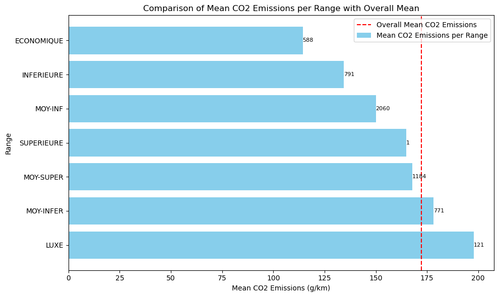

```python
# Plotting the horizontal bar plot
plt.figure(figsize=(10, 6))
bars = plt.barh(mean_co2_gkm_range.index, mean_co2_gkm_range, color='skyblue', label='Mean CO2 Emissions per Range')
plt.axvline(x=overall_mean_co2, color='red', linestyle='--', label='Overall Mean CO2 Emissions')

# Add counts to the right-hand side of each bar
for bar, count in zip(bars, df.groupby('range').size().sort_index()):
    plt.text(bar.get_width(), bar.get_y() + bar.get_height()/2, f'{count}', va='center', fontsize=0.8*plt.rcParams['font.size'])

plt.title('Comparison of Mean CO2 Emissions per Range with Overall Mean')
plt.xlabel('Mean CO2 Emissions (g/km)')
plt.ylabel('Range')
plt.legend()
plt.tight_layout()
plt.show()
```

### b. Exam the mean of CO2 emissions for each variable in **body_type**

```python
# Calculate the mean of 'co2_gkm'
mean_co2_gkm_body_type = df.groupby('body_type')['co2_gkm'].mean()
mean_co2_gkm_body_type = mean_co2_gkm_body_type.sort_values(ascending=False)
overall_mean_co2 = df['co2_gkm'].mean()
```

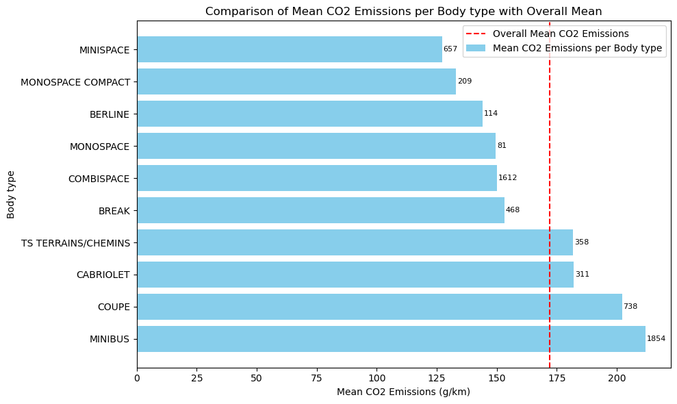

```
Overall Standard Deviation CO2 Emissions:  51.31549439531593
```

```python
# Plotting the horizontal bar plot
plt.figure(figsize=(10, 6))
bars = plt.barh(mean_co2_gkm_body_type.index, mean_co2_gkm_body_type, color='skyblue', label='Mean CO2 Emissions per Body type')
plt.axvline(x=overall_mean_co2, color='red', linestyle='--', label='Overall Mean CO2 Emissions')

# Add counts to the right-hand side of each bar for body type
for bar, count in zip(bars, df.groupby('body_type').size().sort_index()):
    plt.text(bar.get_width() + 0.5, bar.get_y() + bar.get_height()/2, f'{count}', va='center', fontsize=0.8*plt.rcParams['font.size'])

plt.title('Comparison of Mean CO2 Emissions per Body type with Overall Mean')
plt.xlabel('Mean CO2 Emissions (g/km)')
plt.ylabel('Body type')
plt.legend()
plt.tight_layout()
plt.show()


overall_std_co2 = df['co2_gkm'].std()
print('\nOverall Standard Deviation CO2 Emissions: ', overall_std_co2)
```

### c. Exam the mean of CO2 emissions for each variable in **transmission**

```python
# Calculate the mean of 'co2_gkm'
mean_co2_gkm_transmission = df.groupby('transmission')['co2_gkm'].mean()
mean_co2_gkm_transmission = mean_co2_gkm_transmission.sort_values(ascending=False)
overall_mean_co2 = df['co2_gkm'].mean()
```

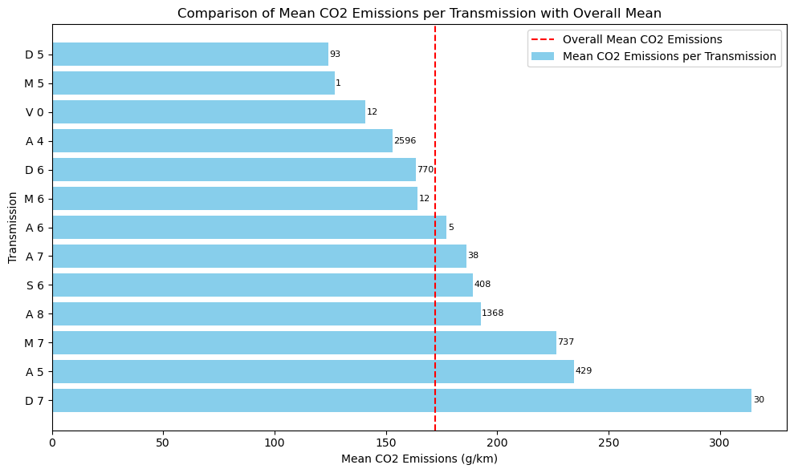

```
Overall Standard Deviation CO2 Emissions:  51.31549439531593
```

```python
# Plotting the horizontal bar plot
plt.figure(figsize=(10, 6))
bars = plt.barh(mean_co2_gkm_transmission.index, mean_co2_gkm_transmission, color='skyblue', label='Mean CO2 Emissions per Transmission')
plt.axvline(x=overall_mean_co2, color='red', linestyle='--', label='Overall Mean CO2 Emissions')

# Add counts to the right-hand side of each bar for body type
for bar, count in zip(bars, df.groupby('transmission').size().sort_index()):
    plt.text(bar.get_width() + 0.5, bar.get_y() + bar.get_height()/2, f'{count}', va='center', fontsize=0.8*plt.rcParams['font.size'])


plt.title('Comparison of Mean CO2 Emissions per Transmission with Overall Mean')
plt.xlabel('Mean CO2 Emissions (g/km)')
plt.ylabel('Transmission')
plt.legend()
plt.tight_layout()
plt.show()


overall_std_co2 = df['co2_gkm'].std()
print('\nOverall Standard Deviation CO2 Emissions: ', overall_std_co2)
```

# 2. Data Processing and Cleaning

We found that **administrative_power** and **maximum_power_kW** have large maximum values away from the mean and high standard deviation, so we will focus on examining the data points in these two variables.

## 2.1 Dealing with The Outliers

### a. Examination of **administrative_power**

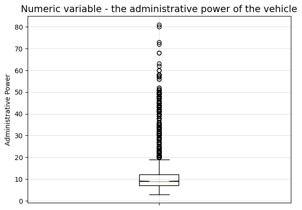

```python
plt.figure(figsize=(7, 5))
plt.boxplot(df.administrative_power, notch=True)
plt.title("Numeric variable - the administrative power of the vehicle",
          size=14)
plt.ylabel("Administrative Power")
plt.xticks([1], [""])
plt.grid(alpha=0.4)
```

```python
df.loc[df['administrative_power'] >= 65.0,
       ['brand', 'administrative_power', 'maximum_power_kW', 'mixed_fuel_consumption', 'co2_gkm']]
```

| id | brand | administrative_power | maximum_power_kW | mixed_fuel_consumption | co2_gkm |
| --- | --- | --- | --- | --- | --- |
| 115 | ASTON MARTIN | 80 | 559.3 | 23.9 | 555 |
| 116 | ASTON MARTIN | 81 | 559.3 | 24.5 | 572 |
| 1382 | FERRARI | 72 | 541.0 | 15.0 | 350 |
| 1383 | FERRARI | 73 | 541.0 | 16.3 | 380 |
| 2698 | LAMBORGHINI | 68 | 515.0 | 16.0 | 370 |
| 2699 | LAMBORGHINI | 68 | 515.0 | 16.0 | 370 |

Despite these 6 outliers (**administrative_power** >= 65) having relatively high administrative power, they also exhibit large maximum power and mixed fuel consumption, so we decide to **keep these 6 extreme outliers unchanged**.

### b. Examination of **maximum_power_kW**

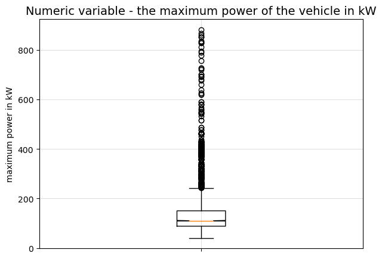

```python
plt.figure(figsize=(7, 5))
plt.boxplot(df.maximum_power_kW, notch=True)
plt.title("Numeric variable - the maximum power of the vehicle in kW",
          size=14)
plt.ylabel("maximum power in kW")
plt.xticks([1], [""])
plt.grid(alpha=0.4)
```

```python
df.loc[df['maximum_power_kW'] >= 700.0,
       ['brand', 'fuel_type', 'administrative_power', 'maximum_power_kW', 'mixed_fuel_consumption', 'co2_gkm']]
```

| id | brand | fuel_type | administrative_power | maximum_power_kW | mixed_fuel_consumption | co2_gkm |
| --- | --- | --- | --- | --- | --- | --- |
| 959 | BMW | GO | 15 | 866.0 | 7.4 | 195 |
| 1067 | CHEVROLET | ES | 8 | 828.0 | 6.4 | 149 |
| 1162 | CITROEN | GO | 6 | 701.0 | 4.0 | 104 |
| 1976 | FIAT | GO | 8 | 790.0 | 7.0 | 183 |
| 2305 | HONDA | GO | 9 | 700.0 | 6.4 | 167 |
| 5148 | MERCEDES-BENZ | ES | 12 | 834.0 | 6.7 | 156 |
| 5642 | MERCEDES-BENZ | ES | 50 | 852.0 | 10.4 | 243 |
| 7689 | MERCEDES-BENZ | GO | 14 | 726.0 | 6.2 | 162 |
| 9303 | MERCEDES-BENZ | EH | 19 | 812.0 | 6.6 | 153 |
| 9668 | MERCEDES-BENZ | GO | 9 | 725.0 | 8.4 | 222 |
| 11731 | MERCEDES-BENZ | GO | 8 | 851.0 | 7.5 | 197 |
| 12797 | MERCEDES-BENZ | GO | 13 | 828.0 | 8.8 | 233 |
| 14580 | MERCEDES-BENZ | GO | 10 | 832.0 | 8.0 | 210 |
| 15748 | MERCEDES-BENZ | GO | 13 | 756.0 | 10.2 | 269 |
| 41841 | MINI | ES | 6 | 794.0 | 6.5 | 152 |
| 42114 | NISSAN | GO | 9 | 777.0 | 7.1 | 188 |
| 42702 | PEUGEOT | ES | 4 | 719.0 | 4.3 | 99 |
| 43063 | RENAULT | GO | 6 | 859.0 | 4.7 | 124 |
| 43618 | SMART | ES | 5 | 881.0 | 4.9 | 114 |

```python
print('Median of administrative_power: ', df['administrative_power'].median())
print('Median of maximum_power_kW: ', df['maximum_power_kW'].median())
print('Median of mixed_fuel_consumption: ', df['mixed_fuel_consumption'].median())
print('Median of co2_gkm: ', df['co2_gkm'].median())
```

```
Median of administrative_power:  9.0
Median of maximum_power_kW:  110.0
Median of mixed_fuel_consumption:  6.6
Median of co2_gkm:  160.0
```

These vehicle models have relatively high **maximum_power_kW**, while their other variables stay in normal range. They might be abnormal values. However, there are so many *MERCEDES-BENZ* vehicles that show up in the table. Therefore, we only replace the values of vehicles with the median of 'maximum_power_kW' for those that aren't *MERCEDES-BENZ*.

## *Revise 2*

```python
median_maximum_power = df['maximum_power_kW'].median()
df.loc[(df['maximum_power_kW'] >= 700.0) & (df['brand'] != 'MERCEDES-BENZ'), 'maximum_power_kW'] = median_maximum_power
```

## 2.2 Dealing with Missing Values

```python
nb_missing_values = df.isna().sum()
nb_missing_values
```

```
brand                             0
commercial_designation            0
utac_model                        0
fuel_type                         0
hybrid                            0
administrative_power              0
maximum_power_kW                  0
transmission                      0
urban_fuel_consumption            3
extra_urban_fuel_consumption    342
mixed_fuel_consumption            0
min_euro_empty_weight           336
max_euro_empty_weight             0
body_type                        97
range                           983
co2_gkm                           0
dtype: int64
```

## a. Finding Missing Value

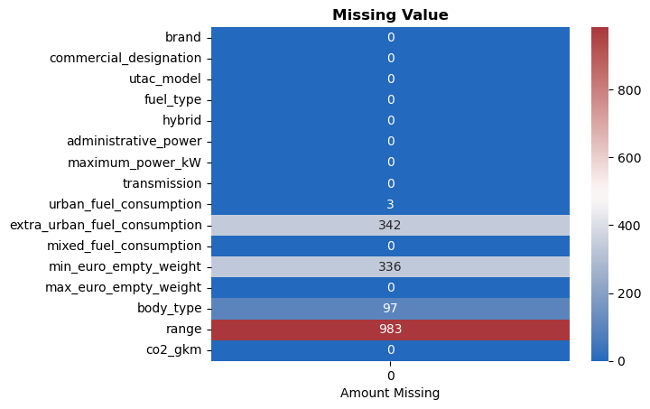

```python
import seaborn as sns

plt.title('Missing Value',fontweight='bold')
ax = sns.heatmap(df.isna().sum().to_frame(),annot=True,fmt='d',cmap='vlag')
ax.set_xlabel('Amount Missing')
plt.show()
```

## b. Filling Missing Value of Float with The Median Method

## *Revise 3*

**After the presentation, we replaced the missing values with median instead of mean**

```python
df['urban_fuel_consumption'].fillna(df['urban_fuel_consumption'].median(), inplace=True)
```

```python
df['extra_urban_fuel_consumption'].fillna(df['extra_urban_fuel_consumption'].median(), inplace=True)
```

```python
df['min_euro_empty_weight'].fillna(df['min_euro_empty_weight'].median(), inplace=True)
```

```python
df.isna().sum()
```

```
brand                             0
commercial_designation            0
utac_model                        0
fuel_type                         0
hybrid                            0
administrative_power              0
maximum_power_kW                  0
transmission                      0
urban_fuel_consumption            0
extra_urban_fuel_consumption      0
mixed_fuel_consumption            0
min_euro_empty_weight             0
max_euro_empty_weight             0
body_type                        97
range                           983
co2_gkm                           0
dtype: int64
```

## c. Filling The Missing Values of String with The Mode

```python
mode_value_body_type = df['body_type'].mode()[0]
mode_value_body_type
```

```
'BERLINE'
```

```python
df['body_type'] = df['body_type'].fillna(mode_value_body_type)
```

```python
mode_value_range = df['range'].mode()[0]
mode_value_range
```

```
'MOY-INFER'
```

```python
df['range'] = df['range'].fillna(mode_value_range)
```

```python
df.isna().sum()
```

```
brand                           0
commercial_designation          0
utac_model                      0
fuel_type                       0
hybrid                          0
administrative_power            0
maximum_power_kW                0
transmission                    0
urban_fuel_consumption          0
extra_urban_fuel_consumption    0
mixed_fuel_consumption          0
min_euro_empty_weight           0
max_euro_empty_weight           0
body_type                       0
range                           0
co2_gkm                         0
dtype: int64
```

## d. Transforming data types

Convert **maximum_power_kW** and **min_euro_empty_weight** into integer

```python
df['maximum_power_kW'] = df['maximum_power_kW'].astype(int)
```

```python
df['min_euro_empty_weight'] = df['min_euro_empty_weight'].astype(int)
```

```python
df_object = df.select_dtypes(include='object')

for col in df_object.columns:
    print(df[col].value_counts())
    print('-------------------')
```

```
brand
MERCEDES-BENZ                2185
BMW                           525
VOLKSWAGEN                    425
FORD                          294
FIAT                          282
AUDI                          242
OPEL                          239
CITROEN                       205
SKODA                         171
NISSAN                        164
PEUGEOT                       159
RENAULT                       152
TOYOTA                        111
VOLVO                         106
SEAT                          104
PORSCHE                        88
MINI                           79
KIA                            76
CHEVROLET                      63
JAGUAR LAND ROVER LIMITED      55
HYUNDAI                        52
JEEP                           50
HONDA                          47
MAZDA                          46
ALFA-ROMEO                     46
CADILLAC                       44
JAGUAR                         43
DANGEL                         39
MERCEDES AMG                   38
LEXUS                          38
MITSUBISHI                     36
SMART                          30
DACIA                          30
LANCIA                         29
ASTON MARTIN                   27
SUBARU                         27
INFINITI                       25
SUZUKI                         24
LAMBORGHINI                    16
```

[output cut: 84 more lines]

```
MONOSPACE COMPACT       209
MONOSPACE               114
MINISPACE                81
Name: count, dtype: int64
-------------------
range
MOY-INFER     3043
LUXE          1184
MOY-SUPER      791
INFERIEURE     771
SUPERIEURE     588
ECONOMIQUE     121
MOY-INF          1
Name: count, dtype: int64
-------------------
```

Convert **hybrid** into boolean

```python
list_to_boolean = ['hybrid']

def transform_hybrid_type(hybrid):
    if  hybrid == 'oui':
        output = True
    else:
        output = False
    return output

df['hybrid'] = df['hybrid'].apply(transform_hybrid_type)
```

```python
df.hybrid
```

```
id
0        False
1        False
2        False
4        False
6        False
         ...
44845    False
44846    False
44847    False
44848    False
44849    False
Name: hybrid, Length: 6499, dtype: bool
```

# 3. Visualization

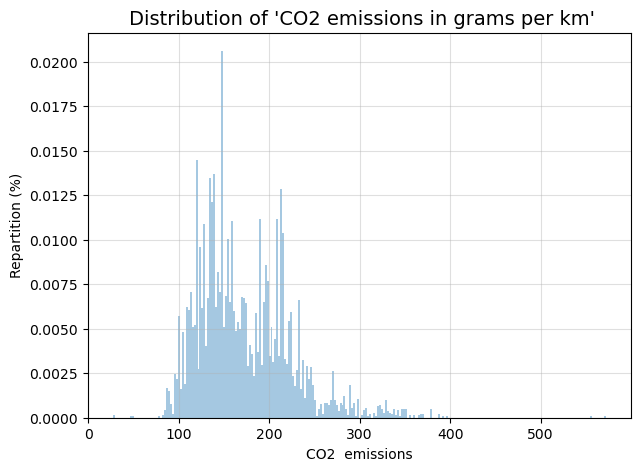

```python
plt.figure(figsize=(7, 5))
plt.hist(df.co2_gkm, density=True, bins=250, alpha=0.4)
plt.title(" Distribution of 'CO2 emissions in grams per km'", size=14)
plt.ylabel("Repartition (%)")
plt.xlabel("CO2  emissions")
plt.grid(alpha=0.4)
plt.show()
```

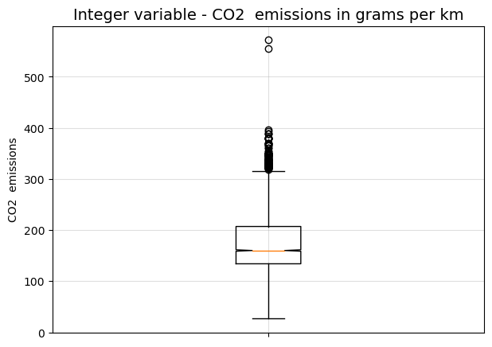

```python
plt.figure(figsize=(7, 5))
plt.boxplot(df.co2_gkm, notch=True)
plt.title("Integer variable - CO2  emissions in grams per km",
          size=14)
plt.ylabel("CO2  emissions")
plt.xticks([1], [""])
plt.grid(alpha=0.4)
```

```python
df.loc[df['co2_gkm'] >= 500]
```

| id | brand | commercial_designation | utac_model | fuel_type | hybrid | administrative_power | maximum_power_kW | transmission | urban_fuel_consumption | extra_urban_fuel_consumption | mixed_fuel_consumption | min_euro_empty_weight | max_euro_empty_weight | body_type | range | co2_gkm |
| --- | --- | --- | --- | --- | --- | --- | --- | --- | --- | --- | --- | --- | --- | --- | --- | --- |
| 115 | ASTON MARTIN | ONE-77 | ONE-77 | ES | False | 80 | 559 | A 6 | 38.9 | 14.5 | 23.9 | 1815 | 1815 | COUPE | LUXE | 555 |
| 116 | ASTON MARTIN | ONE-77 | ONE-77 | ES | False | 81 | 559 | A 6 | 41.1 | 14.9 | 24.5 | 1815 | 1815 | COUPE | LUXE | 572 |

```python
df.loc[(df['brand'] == 'ASTON MARTIN') & (df['co2_gkm'] >= 350),
       ['brand', 'administrative_power', 'maximum_power_kW', 'mixed_fuel_consumption', 'max_euro_empty_weight', 'co2_gkm']]
```

| id | brand | administrative_power | maximum_power_kW | mixed_fuel_consumption | max_euro_empty_weight | co2_gkm |
| --- | --- | --- | --- | --- | --- | --- |
| 115 | ASTON MARTIN | 80 | 559 | 23.9 | 1815 | 555 |
| 116 | ASTON MARTIN | 81 | 559 | 24.5 | 1815 | 572 |
| 141 | ASTON MARTIN | 45 | 380 | 16.4 | 1755 | 388 |
| 143 | ASTON MARTIN | 45 | 380 | 16.4 | 1835 | 388 |
| 179 | ASTON MARTIN | 45 | 380 | 16.4 | 1755 | 388 |

Although there are two extremely high values in **co2_gkm**, we compared these two data with **maximum_power_kW** and **co2_gkm** variables. We found that *ASTON MARTIN* tend to have relatively high values in terms of vehicle model in these two variables. Therefore, they seem not to be the outliers.

# 4. Holdout and Encoding

```python
from sklearn.model_selection import train_test_split
from sklearn.preprocessing import OneHotEncoder, StandardScaler
from sklearn.neighbors import KNeighborsRegressor
from sklearn.model_selection import cross_validate
from sklearn.model_selection import GridSearchCV
from sklearn.metrics import f1_score
import matplotlib.pyplot as plt
from sklearn.model_selection import KFold, StratifiedKFold
import warnings; warnings.simplefilter('ignore')
from sklearn.metrics import confusion_matrix, ConfusionMatrixDisplay
from sklearn.model_selection import cross_val_score
from sklearn.metrics import mean_squared_error, r2_score
```

```python
df.info()
```

```
<class 'pandas.core.frame.DataFrame'>
Index: 6499 entries, 0 to 44849
Data columns (total 16 columns):
 #   Column                        Non-Null Count  Dtype
---  ------                        --------------  -----
 0   brand                         6499 non-null   object
 1   commercial_designation        6499 non-null   object
 2   utac_model                    6499 non-null   object
 3   fuel_type                     6499 non-null   object
 4   hybrid                        6499 non-null   bool
 5   administrative_power          6499 non-null   int64
 6   maximum_power_kW              6499 non-null   int32
 7   transmission                  6499 non-null   object
 8   urban_fuel_consumption        6499 non-null   float64
 9   extra_urban_fuel_consumption  6499 non-null   float64
 10  mixed_fuel_consumption        6499 non-null   float64
 11  min_euro_empty_weight         6499 non-null   int32
 12  max_euro_empty_weight         6499 non-null   int64
 13  body_type                     6499 non-null   object
 14  range                         6499 non-null   object
 15  co2_gkm                       6499 non-null   int64
dtypes: bool(1), float64(3), int32(2), int64(3), object(7)
memory usage: 767.9+ KB
```

## 4.1 One-hot Encoding

```python
# Initialize the OneHotEncoder
ohe = OneHotEncoder()
# create a list with variables you would like to encode
list_encode = ['brand', 'commercial_designation','utac_model', 'fuel_type', 'transmission', 'body_type', 'range']
# Fit and transform the gender, work_type and smoking_status columns
ohe_df = ohe.fit_transform(df[list_encode])
# Create a dataframe for the one-hot-encoded features
df_ohe = pd.DataFrame(ohe_df.toarray(), columns=[col  for array in ohe.categories_ for col in array], index=df.index)
# Concatenate the one-hot-encoded features with the original data
df2 = pd.concat([df[df.columns[~df.columns.isin(list_encode)]], df_ohe], axis=1)
```

## 4.2 Holdout

```python
X = df2.drop('co2_gkm', axis=1)
y = df2['co2_gkm']
```

```python
X_train, X_test, y_train, y_test = train_test_split(X, y, test_size=0.4, random_state=50)
```

```python
X_train.head(3)
```

| id | hybrid | administrative_power | maximum_power_kW | urban_fuel_consumption | extra_urban_fuel_consumption | mixed_fuel_consumption | min_euro_empty_weight | max_euro_empty_weight | ALFA-ROMEO | ASTON MARTIN | ... | MONOSPACE | MONOSPACE COMPACT | TS TERRAINS/CHEMINS | ECONOMIQUE | INFERIEURE | LUXE | MOY-INF | MOY-INFER | MOY-SUPER | SUPERIEURE |
| --- | --- | --- | --- | --- | --- | --- | --- | --- | --- | --- | --- | --- | --- | --- | --- | --- | --- | --- | --- | --- | --- |
| 214 | False | 19 | 221 | 8.8 | 5.9 | 6.9 | 1490 | 1490 | 0.0 | 0.0 | ... | 0.0 | 0.0 | 0.0 | 0.0 | 0.0 | 0.0 | 0.0 | 1.0 | 0.0 | 0.0 |
| 1997 | False | 5 | 70 | 4.7 | 3.6 | 4.0 | 1310 | 1310 | 0.0 | 0.0 | ... | 0.0 | 0.0 | 0.0 | 0.0 | 1.0 | 0.0 | 0.0 | 0.0 | 0.0 | 0.0 |
| 11956 | False | 9 | 95 | 10.2 | 6.8 | 8.0 | 2586 | 2851 | 0.0 | 0.0 | ... | 0.0 | 0.0 | 0.0 | 0.0 | 0.0 | 0.0 | 0.0 | 1.0 | 0.0 | 0.0 |

3 rows × 4076 columns

```python
X_test.head(3)
```

| id | hybrid | administrative_power | maximum_power_kW | urban_fuel_consumption | extra_urban_fuel_consumption | mixed_fuel_consumption | min_euro_empty_weight | max_euro_empty_weight | ALFA-ROMEO | ASTON MARTIN | ... | MONOSPACE | MONOSPACE COMPACT | TS TERRAINS/CHEMINS | ECONOMIQUE | INFERIEURE | LUXE | MOY-INF | MOY-INFER | MOY-SUPER | SUPERIEURE |
| --- | --- | --- | --- | --- | --- | --- | --- | --- | --- | --- | --- | --- | --- | --- | --- | --- | --- | --- | --- | --- | --- |
| 5900 | False | 7 | 100 | 6.4 | 4.5 | 5.2 | 1735 | 1735 | 0.0 | 0.0 | ... | 0.0 | 0.0 | 0.0 | 0.0 | 0.0 | 1.0 | 0.0 | 0.0 | 0.0 | 0.0 |
| 12663 | False | 11 | 120 | 10.3 | 8.2 | 9.0 | 2586 | 2851 | 0.0 | 0.0 | ... | 0.0 | 0.0 | 0.0 | 0.0 | 0.0 | 0.0 | 0.0 | 1.0 | 0.0 | 0.0 |
| 37454 | False | 9 | 100 | 9.5 | 6.7 | 7.7 | 2186 | 2275 | 0.0 | 0.0 | ... | 0.0 | 0.0 | 0.0 | 0.0 | 0.0 | 0.0 | 0.0 | 1.0 | 0.0 | 0.0 |

3 rows × 4076 columns

## 4.3 Convert One-hot Encoding Variables into Boolean Variables

```python
list_df = [X_train, X_test]
for df2 in list_df:
    for col in [col  for array in ohe.categories_ for col in array]:
        df2[col] = df2[col].astype('bool')
```

```python
X_train.dtypes
```

```
hybrid                             bool
administrative_power              int64
maximum_power_kW                  int32
urban_fuel_consumption          float64
extra_urban_fuel_consumption    float64
                                 ...
LUXE                               bool
MOY-INF                            bool
MOY-INFER                          bool
MOY-SUPER                          bool
SUPERIEURE                         bool
Length: 4076, dtype: object
```

```python
X_test.dtypes
```

```
hybrid                             bool
administrative_power              int64
maximum_power_kW                  int32
urban_fuel_consumption          float64
extra_urban_fuel_consumption    float64
                                 ...
LUXE                               bool
MOY-INF                            bool
MOY-INFER                          bool
MOY-SUPER                          bool
SUPERIEURE                         bool
Length: 4076, dtype: object
```

# 5. Scale The Data

```python
stsc = StandardScaler()
# Create a list of numerical columns
numerical_cols = ['administrative_power', 'maximum_power_kW', 'urban_fuel_consumption',
                     'extra_urban_fuel_consumption', 'mixed_fuel_consumption',
                     'min_euro_empty_weight', 'max_euro_empty_weight']
# Fit and transform the numerical columns
X_train[numerical_cols] = stsc.fit_transform(X_train[numerical_cols])
#transform the numerical columns
X_test[numerical_cols] = stsc.transform(X_test[numerical_cols])
```

```python
X_train.head()
```

| id | hybrid | administrative_power | maximum_power_kW | urban_fuel_consumption | extra_urban_fuel_consumption | mixed_fuel_consumption | min_euro_empty_weight | max_euro_empty_weight | ALFA-ROMEO | ASTON MARTIN | ... | MONOSPACE | MONOSPACE COMPACT | TS TERRAINS/CHEMINS | ECONOMIQUE | INFERIEURE | LUXE | MOY-INF | MOY-INFER | MOY-SUPER | SUPERIEURE |
| --- | --- | --- | --- | --- | --- | --- | --- | --- | --- | --- | --- | --- | --- | --- | --- | --- | --- | --- | --- | --- | --- |
| 214 | False | 0.803731 | 1.008677 | -0.011338 | 0.079761 | -0.003824 | -0.660711 | -0.673854 | False | False | ... | False | False | False | False | False | False | False | True | False | False |
| 1997 | False | -0.730701 | -0.776068 | -1.197853 | -1.422124 | -1.308076 | -1.091666 | -1.041119 | False | False | ... | False | False | False | False | True | False | False | False | False | False |
| 11956 | False | -0.292291 | -0.480580 | 0.393813 | 0.667455 | 0.490893 | 1.963328 | 2.103074 | False | False | ... | False | False | False | False | False | False | False | True | False | False |
| 44714 | False | -0.401894 | -0.386024 | -0.561187 | -0.442634 | -0.498540 | -0.268063 | -0.339235 | False | False | ... | False | False | False | False | False | False | False | False | True | False |
| 14082 | False | -0.292291 | -0.480580 | 0.422753 | 0.732755 | 0.580841 | 1.963328 | 2.119397 | False | False | ... | False | False | False | False | False | False | False | True | False | False |

5 rows × 4076 columns

# 6. K-Nearest Neighbors (KNN) & K-fold Cross-Validation

The model exams the performance of the prediction of training dataset with all the meaningful variables.

```python
features = ['administrative_power', 'maximum_power_kW', 'urban_fuel_consumption',
            'extra_urban_fuel_consumption', 'mixed_fuel_consumption', 'min_euro_empty_weight',
            'max_euro_empty_weight', 'hybrid']

X_train_features = X_train[features]
X_test_features = X_test[features]
```

```python
k = 5
knn_reg = KNeighborsRegressor(n_neighbors=k)

# Train the K-neighbors model
knn_reg.fit(X_train_features, y_train)

# Predict on test set
y_pred_knn = knn_reg.predict(X_test_features)

# Calculate MSE for K-neighbors
mse_knn = mean_squared_error(y_test, y_pred_knn)
print("Mean Squared Error (MSE) for K-nearest neighbors:", round(mse_knn, 2))

# Calculate R^2 for K-neighbors
r2_knn = r2_score(y_test, y_pred_knn)

# Calculate adjusted R^2 for K-neighbors
n = len(y_test)
p = len(features)
adj_r2_knn = 1 - ((1 - r2_knn) * (n - 1) / (n - p - 1))
print("Adjusted R^2 score for K-nearest neighbors:", round(adj_r2_knn, 2))
```

```
Mean Squared Error (MSE) for K-nearest neighbors: 30.85
Adjusted R^2 score for K-nearest neighbors: 0.99
```

```python
# K-fold cross-validation
cv_k = 5
knn_reg_cv = KNeighborsRegressor(n_neighbors=5)


# Run K-fold cross-validation
cv_scores = cross_val_score(knn_reg_cv, X_train_features, y_train, cv=cv_k, scoring='r2')

# Calculate MSE for K-fold cross-validation
mse_folds = -cross_val_score(knn_reg_cv, X_train_features, y_train, cv=cv_k, scoring='neg_mean_squared_error')


print("Mean Squared Error (MSE) for K-folds:", mse_folds)
print("Mean of MSE for K-folds:", round(np.mean(mse_folds), 2))
print("Standard Deviation of MSE:", round(np.std(mse_folds), 2))


# Calculate adjusted R^2 for K-fold cross-validation
r2_cv = cv_scores.mean()
adj_r2_cv = 1 - ((1 - r2_cv) * (n - 1) / (n - p - 1))
print("Adjusted R^2 score for K-fold cross-validation:", round(adj_r2_cv, 2))
```

```
Mean Squared Error (MSE) for K-folds: [65.86117949 56.6025641  33.67758974 28.03102564 62.52426187]
Mean of MSE for K-folds: 49.34
Standard Deviation of MSE: 15.48
Adjusted R^2 score for K-fold cross-validation: 0.98
```

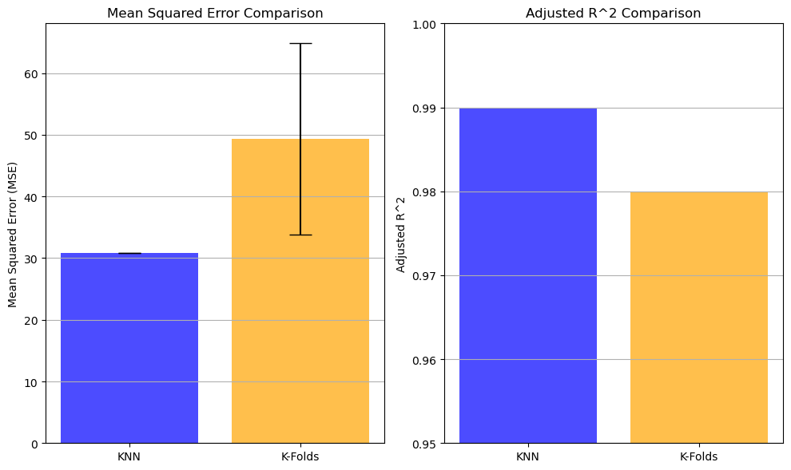

```python
import matplotlib.pyplot as plt

# Data
mse_knn = 30.85
adj_r2_knn = 0.99

mse_kfolds = [65.86117949, 56.6025641, 33.67758974, 28.03102564, 62.52426187]
mean_mse_kfolds = 49.34
std_mse_kfolds = 15.48
adj_r2_kfolds = 0.98

# Plotting
plt.figure(figsize=(10, 6))

# Plot MSE
plt.subplot(1, 2, 1)
plt.bar(["KNN", "K-Folds"], [mse_knn, mean_mse_kfolds], yerr=[0, std_mse_kfolds], color=['blue', 'orange'], alpha=0.7, capsize=10)
plt.ylabel('Mean Squared Error (MSE)')
plt.title('Mean Squared Error Comparison')
plt.grid(axis='y')

# Plot Adjusted R^2
plt.subplot(1, 2, 2)
plt.bar(["KNN", "K-Folds"], [adj_r2_knn, adj_r2_kfolds], color=['blue', 'orange'], alpha=0.7)
plt.ylabel('Adjusted R^2')
plt.title('Adjusted R^2 Comparison')
plt.ylim(0.95, 1)  # Limiting y-axis for better visualization
plt.grid(axis='y')

plt.tight_layout()
plt.show()
```

# 7. Grid Search

## 7.1 Grid search 1

(Using hyperparameter tuning with k-fold)

```python
k_grid = np.arange(1, 10, 1)
output_mean = []
for k in k_grid:
    knn = KNeighborsRegressor(n_neighbors=k)
    results_k = cross_validate(knn, X_train_features, y_train, cv=5,
                               scoring ="neg_mean_squared_error")
    mse_k = -np.mean(results_k["test_score"])
    output_mean.append(mse_k)
```

```python
output_mean
```

```
[36.11572561798493,
 36.54086559033606,
 42.221877562365364,
 46.41627279385142,
 49.339324169711325,
 51.07975290660464,
 53.799741178193415,
 56.025918105682834,
 58.27045811608214]
```

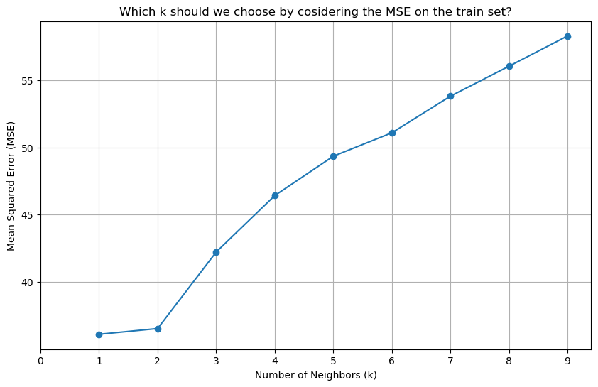

```python
plt.figure(figsize=(10, 6))
plt.plot(k_grid, output_mean, marker='o', linestyle='-')
plt.title('Which k should we choose by cosidering the MSE on the train set?')
plt.xlabel('Number of Neighbors (k)')
plt.ylabel('Mean Squared Error (MSE)')
plt.xticks(np.arange(0, 10, step=1))
plt.grid(True)
plt.show()
```

## 7.2 Grid search 2

(Deciding the best parameters for the **'weights'** and **'metric'** )

```python
# Define the parameter grid
param_grid = {
    'n_neighbors': [1, 3, 5, 7, 9, 11, 15],  # can be adjusted
    'weights': ['uniform', 'distance'],
    'metric' : ['euclidean', 'manhattan']
}

# Perform grid search with k-fold cross-validation
grid_search = GridSearchCV(KNeighborsRegressor(), param_grid, cv=3, scoring='neg_mean_squared_error')
grid_search.fit(X_train_features, y_train)
```

```
GridSearchCV(cv=3, estimator=KNeighborsRegressor(),
             param_grid={'metric': ['euclidean', 'manhattan'],
                         'n_neighbors': [1, 3, 5, 7, 9, 11, 15],
                         'weights': ['uniform', 'distance']},
             scoring='neg_mean_squared_error')
```

```python
# Get the best model
best_knn_reg = grid_search.best_estimator_

# Predict on the test set using the best model
y_pred_grid = best_knn_reg.predict(X_test_features)

# Calculate MSE for the best model
mse_grid = mean_squared_error(y_test, y_pred_grid)
print("Mean Squared Error (MSE) for grid search with k-fold:", round(mse_grid, 2))

# Print the best hyperparameters found by the grid search
print("Best hyperparameters:", grid_search.best_params_)
```

```
Mean Squared Error (MSE) for grid search with k-fold: 19.25
Best hyperparameters: {'metric': 'manhattan', 'n_neighbors': 5, 'weights': 'distance'}
```

# 8. Model Selection - Evaluating The Importance of Variables

## 8.1 K-Nearest Neighbors (KNN) Regression Model

Based on the best parameters from the grid search, we run the KNN regression model with K-fold to rank feature importance scores by permuting the current feature and observing the change in Mean Squared Error.

```python
from sklearn.neighbors import KNeighborsRegressor
from sklearn.model_selection import KFold
from sklearn.metrics import mean_squared_error
import numpy as np
```

```python
# Best hyperparameters from grid search
best_hyperparameters = {'metric': 'manhattan', 'n_neighbors': 5, 'weights': 'distance'}

# Numeric features
numeric_features = ['administrative_power', 'maximum_power_kW', 'urban_fuel_consumption',
                    'extra_urban_fuel_consumption', 'mixed_fuel_consumption', 'min_euro_empty_weight',
                    'max_euro_empty_weight']

X_train_numeric_features = X_train[numeric_features]
y_train = y_train
```

```python
# Initialize K-nearest neighbors regressor with best hyperparameters
knn_reg = KNeighborsRegressor(**best_hyperparameters)

# Define the number of folds for cross-validation
k = 3
kf = KFold(n_splits=k, shuffle=True, random_state=42)

# Initialize an array to store feature importance scores
feature_importance_scores = np.zeros(len(numeric_features))

# Calculate base MSE without permuting features
mse_scores = []
for fold, (train_idx, val_idx) in enumerate(kf.split(X_train_numeric_features, y_train)):
    X_train_fold, X_val_fold = X_train_numeric_features.iloc[train_idx], X_train_numeric_features.iloc[val_idx]
    y_train_fold, y_val_fold = y_train.iloc[train_idx], y_train.iloc[val_idx]
    knn_reg.fit(X_train_fold, y_train_fold)
    y_pred_val = knn_reg.predict(X_val_fold)
    mse_scores.append(mean_squared_error(y_val_fold, y_pred_val))

# Iterate over each feature
for i, feature in enumerate(numeric_features):
    # Initialize an array to store MSE scores with permuted feature
    mse_permuted = np.zeros(k)

    # Iterate over each fold
    for fold, (train_idx, val_idx) in enumerate(kf.split(X_train_numeric_features, y_train)):
        X_train_fold, X_val_fold = X_train_numeric_features.iloc[train_idx], X_train_numeric_features.iloc[val_idx]
        y_train_fold, y_val_fold = y_train.iloc[train_idx], y_train.iloc[val_idx]

        # Copy the training data and randomly permute the current feature
        X_train_permuted = X_train_fold.copy()
        X_train_permuted[feature] = np.random.permutation(X_train_permuted[feature])

        # Train a K-nearest neighbors regression model
        knn_reg.fit(X_train_permuted, y_train_fold)

        # Predict on the validation set
        y_pred_val = knn_reg.predict(X_val_fold)

        # Compute MSE for this fold with permuted feature
        mse_permuted[fold] = mean_squared_error(y_val_fold, y_pred_val)

    # Calculate the change in MSE caused by permuting the current feature
    feature_importance_scores[i] = np.mean(mse_permuted) - np.mean(mse_scores)

# Create a dictionary mapping feature names to their importance scores
feature_importance_dict = dict(zip(numeric_features, feature_importance_scores))

# Sort features by their importance scores in descending order
sorted_features = sorted(feature_importance_dict.items(), key=lambda x: x[1], reverse=True)

# Print the ranking of key variables
print("Ranking of key variables based on feature importance scores:")
for rank, (numeric_feature, importance_score) in enumerate(sorted_features, start=1):
    print(f"{rank}. {numeric_feature}: {importance_score}")
```

```
Ranking of key variables based on feature importance scores:
1. mixed_fuel_consumption: 45.71504922580429
2. urban_fuel_consumption: 43.41157509859208
3. administrative_power: 27.840364522439423
4. extra_urban_fuel_consumption: 26.161618639633325
5. maximum_power_kW: 18.58451738898215
6. max_euro_empty_weight: 17.289298499231435
7. min_euro_empty_weight: 14.358616100380566
```

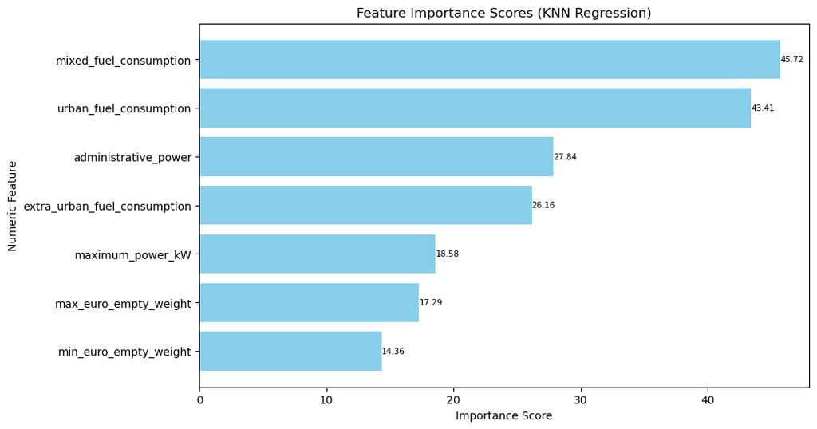

```python
import matplotlib.pyplot as plt

# Extracting sorted feature names and importance scores
sorted_numeric_features = [feature[0] for feature in sorted_features]
sorted_importance_scores = [feature[1] for feature in sorted_features]

# Plotting feature importance scores
plt.figure(figsize=(10, 6))
bars = plt.barh(sorted_numeric_features, sorted_importance_scores, color='skyblue')
plt.xlabel('Importance Score')
plt.ylabel('Numeric Feature')
plt.title('Feature Importance Scores (KNN Regression)')
plt.gca().invert_yaxis()  # Invert y-axis to show the most important features at the top

# Add importance scores on the right-hand side of each bar
for bar, score in zip(bars, sorted_importance_scores):
    plt.text(bar.get_width(), bar.get_y() + bar.get_height()/2, f'{score:.2f}',
             va='center', ha='left', fontsize=0.75*plt.rcParams['font.size'])

plt.show()
```

## 8.2 Linear Regression

The coefficients represent the change in the CO2 emissions for an one-unit change in the corresponding variable, assuming all other variables are fixed.

```python
from sklearn.linear_model import LinearRegression
from sklearn.model_selection import KFold
from sklearn.linear_model import ElasticNet
```

```python
numeric_features = ['administrative_power', 'maximum_power_kW', 'urban_fuel_consumption',
            'extra_urban_fuel_consumption', 'mixed_fuel_consumption', 'min_euro_empty_weight',
            'max_euro_empty_weight']

X_train_numeric_features = X_train[numeric_features]
y_train = y_train
```

```python
# Initialize Linear Regression model
lin_reg = LinearRegression()

# Define the number of folds for cross-validation
k = 5
kf = KFold(n_splits=k, shuffle=True, random_state=42)

# Initialize an array to store feature importance scores
feature_importance_scores = np.zeros(len(numeric_features))  # Use length of numeric_features

# Iterate over each fold
for train_idx, val_idx in kf.split(X_train_numeric_features, y_train):
    X_train_fold, X_val_fold = X_train_numeric_features.iloc[train_idx], X_train_numeric_features.iloc[val_idx]
    y_train_fold, y_val_fold = y_train.iloc[train_idx], y_train.iloc[val_idx]

    # Train a linear regression model
    lin_reg.fit(X_train_fold, y_train_fold)

    # Compute absolute feature importance scores (absolute coefficients)
    feature_importance_scores += np.abs(lin_reg.coef_)

# Average feature importance scores across all folds
average_feature_importance_scores = feature_importance_scores / k

# Create a dictionary mapping feature names to their average importance scores
feature_importance_dict = dict(zip(numeric_features, average_feature_importance_scores))

# Sort features by their average importance scores in descending order
sorted_features = sorted(feature_importance_dict.items(), key=lambda x: x[1], reverse=True)

# Print the ranking of key variables
print("Ranking of key variables:")
for rank, (numeric_feature, importance_score) in enumerate(sorted_features, start=1):
    print(f"{rank}. {numeric_feature}: {importance_score}")
```

```
Ranking of key variables:
1. mixed_fuel_consumption: 52.883477128743586
2. max_euro_empty_weight: 8.815178585919938
3. urban_fuel_consumption: 7.889962915965886
4. administrative_power: 2.801819237408968
5. maximum_power_kW: 1.4787091310212974
6. min_euro_empty_weight: 0.7673193353460311
7. extra_urban_fuel_consumption: 0.7358097992856902
```

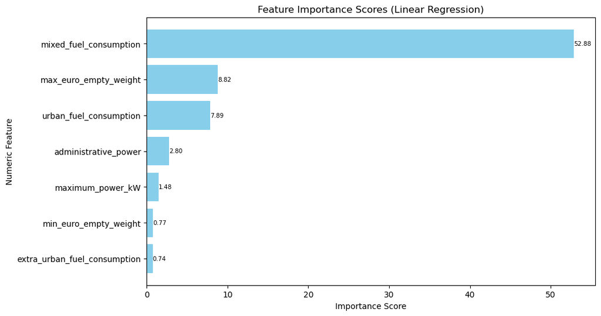

```python
import matplotlib.pyplot as plt

# Extracting sorted feature names and importance scores
sorted_numeric_features = [feature[0] for feature in sorted_features]
sorted_importance_scores = [feature[1] for feature in sorted_features]

# Plotting feature importance scores
plt.figure(figsize=(10, 6))
bars = plt.barh(sorted_numeric_features, sorted_importance_scores, color='skyblue')
plt.xlabel('Importance Score')
plt.ylabel('Numeric Feature')
plt.title('Feature Importance Scores (Linear Regression)')
plt.gca().invert_yaxis()  # Invert y-axis to show the most important features at the top

# Add importance scores on the right-hand side of each bar
for bar, score in zip(bars, sorted_importance_scores):
    plt.text(bar.get_width(), bar.get_y() + bar.get_height()/2, f'{score:.2f}',
             va='center', ha='left', fontsize=0.75*plt.rcParams['font.size'])

plt.show()
```

## 8.3 Elastic-Net

To avoid overfitting, we used the **Elastic-Net**, which combined L1 and L2 regularization, allowing to penalize the residuals.

```python
# Initialize Elastic Net model
elastic_net = ElasticNet(alpha=1.0, l1_ratio=0.5)  # You can adjust alpha and l1_ratio as needed

# Define the number of folds for cross-validation
k = 5
kf = KFold(n_splits=k, shuffle=True, random_state=42)

# Initialize an array to store feature importance scores
feature_importance_scores = np.zeros(len(numeric_features))  # Use length of numeric_features

# Iterate over each fold
for train_idx, val_idx in kf.split(X_train_numeric_features, y_train):
    X_train_fold, X_val_fold = X_train_numeric_features.iloc[train_idx], X_train_numeric_features.iloc[val_idx]
    y_train_fold, y_val_fold = y_train.iloc[train_idx], y_train.iloc[val_idx]

    # Train an Elastic Net model
    elastic_net.fit(X_train_fold, y_train_fold)

    # Compute absolute feature importance scores (absolute coefficients)
    feature_importance_scores += np.abs(elastic_net.coef_)

# Average feature importance scores across all folds
average_feature_importance_scores = feature_importance_scores / k

# Create a dictionary mapping feature names to their average importance scores
feature_importance_dict = dict(zip(numeric_features, average_feature_importance_scores))

# Sort features by their average importance scores in descending order
sorted_features = sorted(feature_importance_dict.items(), key=lambda x: x[1], reverse=True)

# Print the ranking of key variables
print("Ranking of key variables:")
for rank, (numeric_feature, importance_score) in enumerate(sorted_features, start=1):
    print(f"{rank}. {numeric_feature}: {importance_score}")
```

```
Ranking of key variables:
1. mixed_fuel_consumption: 12.117321602404287
2. urban_fuel_consumption: 11.100514122618947
3. extra_urban_fuel_consumption: 10.564672134056709
4. max_euro_empty_weight: 6.367612472409217
5. min_euro_empty_weight: 5.395141307895226
6. administrative_power: 4.8033979795947275
7. maximum_power_kW: 1.8226310352136579
```

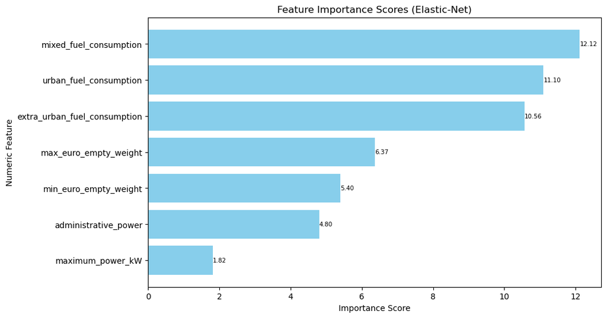

```python
import matplotlib.pyplot as plt

# Extracting sorted feature names and importance scores
sorted_numeric_features = [feature[0] for feature in sorted_features]
sorted_importance_scores = [feature[1] for feature in sorted_features]

# Plotting feature importance scores
plt.figure(figsize=(10, 6))
bars = plt.barh(sorted_numeric_features, sorted_importance_scores, color='skyblue')
plt.xlabel('Importance Score')
plt.ylabel('Numeric Feature')
plt.title('Feature Importance Scores (Elastic-Net)')
plt.gca().invert_yaxis()  # Invert y-axis to show the most important features at the top

# Add importance scores on the right-hand side of each bar
for bar, score in zip(bars, sorted_importance_scores):
    plt.text(bar.get_width(), bar.get_y() + bar.get_height()/2, f'{score:.2f}',
             va='center', ha='left', fontsize=0.75*plt.rcParams['font.size'])

plt.show()
```

## 8.4 Decision Tree - Classification and Regression Trees (CART)

Besides using linear regression, we also try another method here to evaluate the importance of difference variables, which is one of the most popular decision tree algorithms -- CART. Among different decision tree algorithms, we chose CART becasue it can deal with both continuous and categorical features. And it provides a measure of variable importance, which indicates how much each feature contributes to the model's predictions.

```python
from sklearn.tree import DecisionTreeRegressor
import matplotlib.pyplot as plt
```

```python
numeric_features = ['administrative_power', 'maximum_power_kW', 'urban_fuel_consumption',
                    'extra_urban_fuel_consumption', 'mixed_fuel_consumption', 'min_euro_empty_weight',
                    'max_euro_empty_weight']
X_train_numeric_features = X_train[numeric_features]
y_train = y_train
```

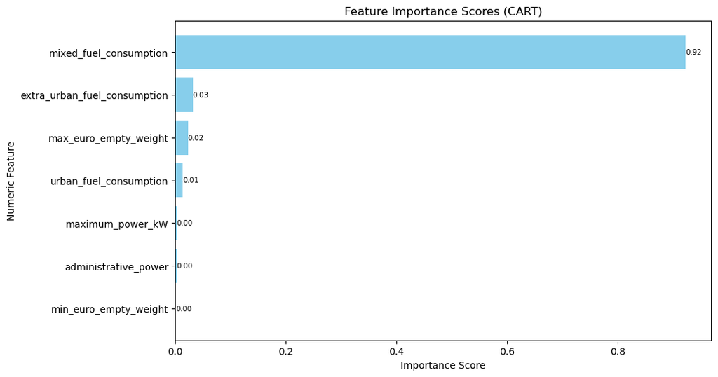

```python
# Initialize Decision Tree model
tree_reg = DecisionTreeRegressor(random_state=42)

# Train the Decision Tree model
tree_reg.fit(X_train_numeric_features, y_train)

# Extract feature importances
importances = tree_reg.feature_importances_

# Create a dictionary mapping feature names to their importance scores
feature_importance_dict = dict(zip(numeric_features, importances))

# Sort features by their importance scores in descending order
sorted_features = sorted(feature_importance_dict.items(), key=lambda x: x[1], reverse=True)

# Extract sorted feature names and importance scores
sorted_feature_names = [feature[0] for feature in sorted_features]
sorted_importance_scores = [feature[1] for feature in sorted_features]

# Plot feature importances
plt.figure(figsize=(10, 6))
bars = plt.barh(sorted_feature_names, sorted_importance_scores, color='skyblue')
plt.xlabel('Importance Score')
plt.ylabel('Numeric Feature')
plt.title('Feature Importance Scores (CART)')
plt.gca().invert_yaxis()  # Invert y-axis to show the most important features at the top

# Add importance scores on the right-hand side of each bar
for bar, score in zip(bars, sorted_importance_scores):
    plt.text(bar.get_width(), bar.get_y() + bar.get_height()/2, f'{score:.2f}',
             va='center', ha='left', fontsize=0.75*plt.rcParams['font.size'])

plt.show()
```

## 8.5 Random Forest

(Based on the result in the CART model, we trained the random forest)

But there is drawback in decision tree algorithms, which is high variance. They does not generalize the pattern well, and will lead to overfitting. To address this problem, we use ensemble methods which combine several predictive models to produce optimal predictive model.

Here we use Random Forest, because it can add more randomness, further reduce the variance, and thus provide more robust estimates of variable importance compared to a single decision tree like CART.

And we can evaluate the importance of variables in random forest by looking at how frequently the variables are used by trees. The more they are used at the 'top' of the trees, the more important the variable is.

```python
from sklearn.ensemble import RandomForestRegressor
```

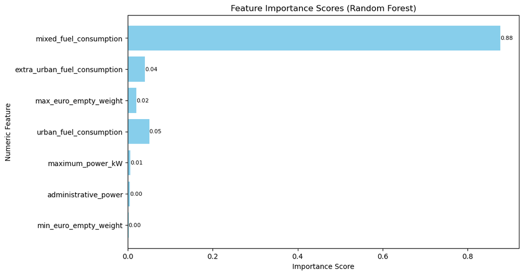

```python
# Extract the selected variables from the sorted feature list (e.g., top 5)
selected_variables = [feature[0] for feature in sorted_features[:7]]

X_train_selected = X_train_numeric_features[selected_variables]

# Initialize Random Forest model
forest_reg = RandomForestRegressor(n_estimators=100, random_state=42)

# Train the Random Forest model using the selected variables
forest_reg.fit(X_train_selected, y_train)

# Extract feature importances
importances = forest_reg.feature_importances_

# Plot feature importances
plt.figure(figsize=(10, 6))
bars = plt.barh(selected_variables, importances, color='skyblue')
plt.xlabel('Importance Score')
plt.ylabel('Numeric Feature')
plt.title('Feature Importance Scores (Random Forest)')
plt.gca().invert_yaxis()  # Invert y-axis to show the most important features at the top

# Add importance scores on the right-hand side of each bar
for bar, score in zip(bars, importances):
    plt.text(bar.get_width(), bar.get_y() + bar.get_height()/2, f'{score:.2f}',
             va='center', ha='left', fontsize=0.8*plt.rcParams['font.size'])

plt.show()
```

# 9. Cross-Check Result

Ranking of importance of key variables:

1. mixed_fuel_consumption
2. urban_fuel_consumption
3. extra_urban_fuel_consumption
4. max_euro_empty_weight
5. administrative_power
6. maximum_power_kW
7. min_euro_empty_weight

```python
import seaborn as sns
```

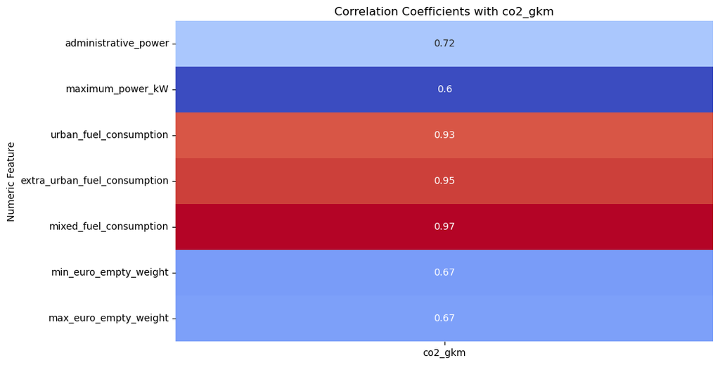

```python
# Concatenate independent and dependent variables
features = ['administrative_power', 'maximum_power_kW', 'urban_fuel_consumption',
            'extra_urban_fuel_consumption', 'mixed_fuel_consumption', 'min_euro_empty_weight',
            'max_euro_empty_weight']

X_train_features = X_train[features]

data = X_train_features.copy()
data['co2_gkm'] = y_train

# Calculate correlation coefficients
correlation_matrix = data.corr()

# Extract correlations with the dependent variable
correlation_with_target = correlation_matrix['co2_gkm'].drop('co2_gkm')

# Visualize the correlation coefficients
plt.figure(figsize=(10, 6))
sns.heatmap(correlation_with_target.to_frame(), annot=True, cmap='coolwarm', cbar=False)
plt.title('Correlation Coefficients with co2_gkm')
plt.ylabel('Numeric Feature')
plt.show()
```

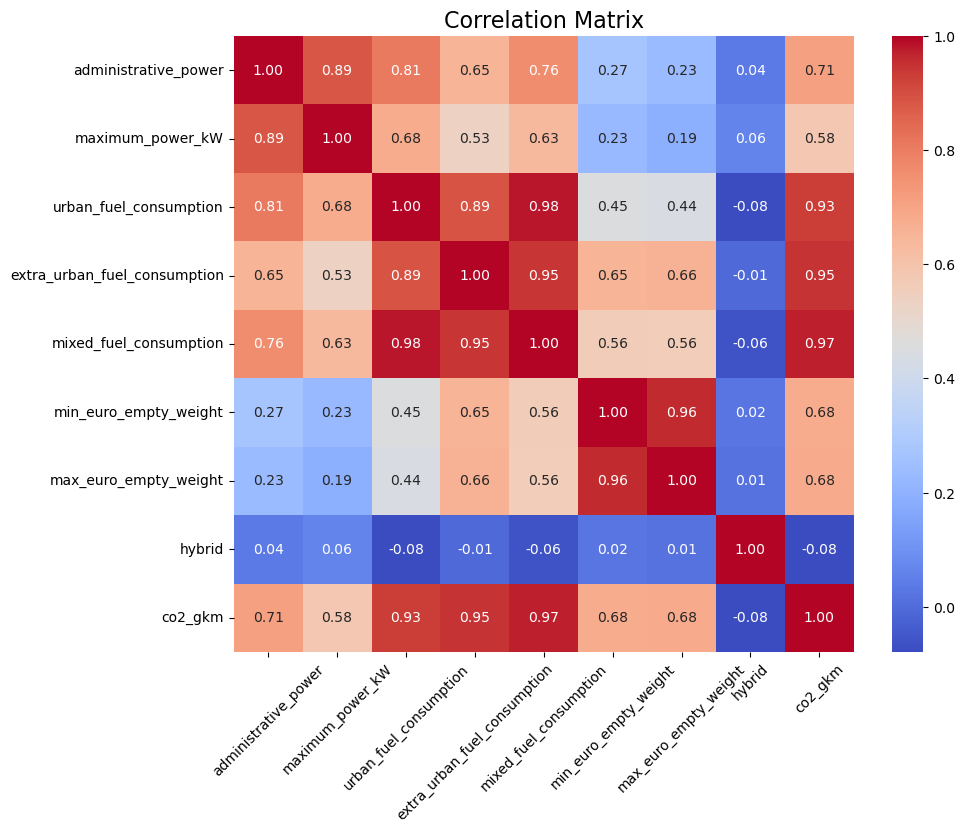

```python
# Define the features for correlation analysis
features = ['administrative_power', 'maximum_power_kW', 'urban_fuel_consumption',
            'extra_urban_fuel_consumption', 'mixed_fuel_consumption', 'min_euro_empty_weight',
            'max_euro_empty_weight', 'hybrid', 'co2_gkm']

# Create a correlation matrix
correlation_matrix = df[features].corr()

# Plot the correlation matrix using Seaborn
plt.figure(figsize=(10, 8))
sns.heatmap(correlation_matrix, annot=True, cmap='coolwarm', fmt=".2f", annot_kws={"size": 10})
plt.title('Correlation Matrix', fontsize=16)
plt.xticks(rotation=45)
plt.yticks(rotation=0)
plt.show()
```

## 10. Prediction Model

```python
import numpy as np
import pandas as pd
from sklearn.ensemble import RandomForestRegressor
import ipywidgets as widgets
from ipywidgets import interact, FloatSlider, Layout, fixed
```

```python
numeric_features = ['administrative_power', 'maximum_power_kW', 'urban_fuel_consumption',
                    'extra_urban_fuel_consumption', 'mixed_fuel_consumption', 'min_euro_empty_weight',
                    'max_euro_empty_weight']
X_train_numeric_features = X_train[numeric_features]
y_train = y_train
```

```python
# Define the model
model = RandomForestRegressor()
model.fit(X_train_numeric_features, y_train)

# Define function for prediction and showing results
def predict_and_show(administrative_power, maximum_power_kW, urban_fuel_consumption,
                     extra_urban_fuel_consumption, mixed_fuel_consumption, min_euro_empty_weight,
                     max_euro_empty_weight):
    # Create a dataframe from input values
    data = pd.DataFrame([[administrative_power, maximum_power_kW, urban_fuel_consumption,
                          extra_urban_fuel_consumption, mixed_fuel_consumption, min_euro_empty_weight,
                          max_euro_empty_weight]],
                        columns=['administrative_power', 'maximum_power_kW', 'urban_fuel_consumption',
                                 'extra_urban_fuel_consumption', 'mixed_fuel_consumption', 'min_euro_empty_weight',
                                 'max_euro_empty_weight'])
    # Predict using the model
    prediction = model.predict(data)
    # Show the prediction
    print("Predicted CO2 emissions (g/km):", prediction[0])

# Create sliders for each variable with larger size and font
layout = Layout(width='60%')  # Adjust the width as needed
interact(predict_and_show,
         administrative_power=FloatSlider(min=0, max=20, step=0.1, value=11, description='Administrative Power:',
                                           layout=layout, style={'description_width': 'initial'}),
         maximum_power_kW=FloatSlider(min=0, max=500, step=1, value=135, description='Maximum Power (kW):',
                                       layout=layout, style={'description_width': 'initial'}),
         urban_fuel_consumption=FloatSlider(min=0, max=10, step=0.1, value=5.5, description='Urban Fuel Consumption:',
                                             layout=layout, style={'description_width': 'initial'}),
         extra_urban_fuel_consumption=FloatSlider(min=0, max=10, step=0.1, value=2.5,
                                                   description='Extra Urban Fuel Consumption:',
                                                   layout=layout, style={'description_width': 'initial'}),
         mixed_fuel_consumption=FloatSlider(min=0, max=10, step=0.1, value=1.5, description='Mixed Fuel Consumption:',
                                            layout=layout, style={'description_width': 'initial'}),
         min_euro_empty_weight=FloatSlider(min=0, max=5000, step=10, value=1774, description='Min Euro Empty Weight:',
                                            layout=layout, style={'description_width': 'initial'}),
         max_euro_empty_weight=FloatSlider(min=0, max=5000, step=10, value=1826, description='Max Euro Empty Weight:',
                                            layout=layout, style={'description_width': 'initial'}))
```

```
interactive(children=(FloatSlider(value=11.0, description='Administrative Power:', layout=Layout(width='60%'),…
```

```
<function __main__.predict_and_show(administrative_power, maximum_power_kW, urban_fuel_consumption, extra_urban_fuel_consumption, mixed_fuel_consumption, min_euro_empty_weight, max_euro_empty_weight)>
```

```python
df.describe()
```

|  | administrative_power | maximum_power_kW | urban_fuel_consumption | extra_urban_fuel_consumption | mixed_fuel_consumption | min_euro_empty_weight | max_euro_empty_weight | co2_gkm |
| --- | --- | --- | --- | --- | --- | --- | --- | --- |
| count | 6499.000000 | 6499.000000 | 6499.000000 | 6499.000000 | 6499.000000 | 6499.000000 | 6499.000000 | 6499.000000 |
| mean | 11.608863 | 135.173565 | 8.817290 | 5.769572 | 6.896623 | 1770.524388 | 1826.030466 | 172.136329 |
| std | 8.920942 | 83.499406 | 3.389138 | 1.510078 | 2.183987 | 418.934332 | 492.325497 | 51.315494 |
| min | 3.000000 | 40.000000 | 0.000000 | 2.800000 | 1.200000 | 825.000000 | 825.000000 | 27.000000 |
| 25% | 7.000000 | 88.000000 | 6.500000 | 4.600000 | 5.300000 | 1493.000000 | 1490.500000 | 134.000000 |
| 50% | 9.000000 | 110.000000 | 8.300000 | 5.500000 | 6.600000 | 1699.000000 | 1715.000000 | 160.000000 |
| 75% | 12.000000 | 147.000000 | 10.100000 | 6.700000 | 8.100000 | 2043.000000 | 2141.000000 | 207.000000 |
| max | 81.000000 | 852.000000 | 41.100000 | 14.900000 | 24.500000 | 2905.000000 | 3115.000000 | 572.000000 |

```python
desktop_path = "/Users/CHIENWEI/Desktop/"
```

```python
filename = 'CO2_emissions_data_for_copulas.csv'
filepath = desktop_path + filename
```

```python
df.to_csv(filepath, index=False)
```